# Lab 8 - Introduction to Mixture Models

Structural Equation Modeling - Instructor: Karen Nylund-Gibson

Adam Garber

May 22, 2020

`University of California, Santa Barbara`

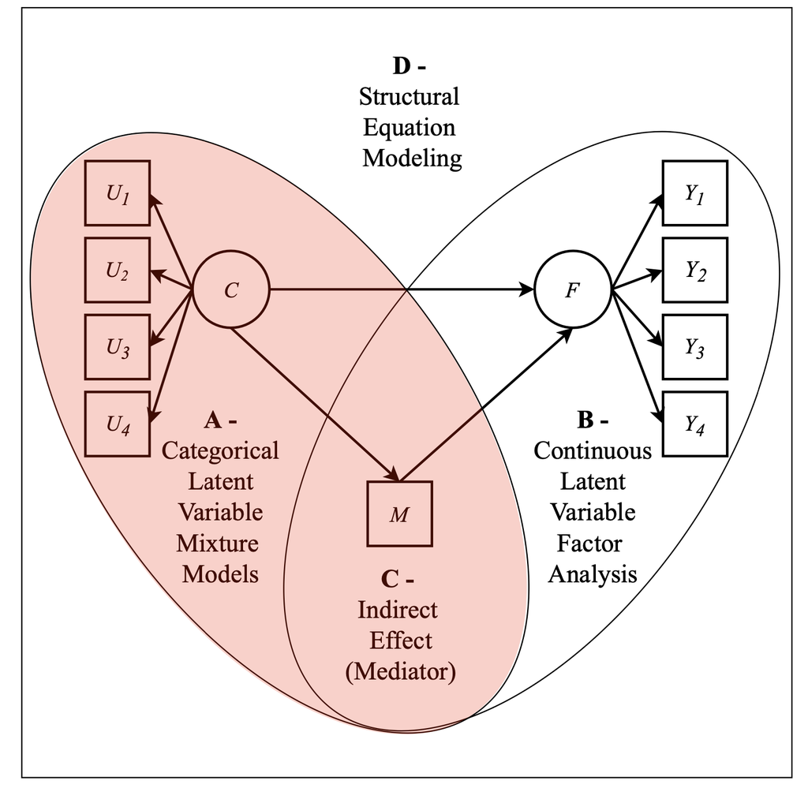

*Figure*. Picture has been adapted from study by Múthen, 2006.

# Lab preparation

## Creating a version-controlled R-Project with Github

Download repository here: https://github.com/garberadamc/SEM-Lab8

On the Github repository webpage:

1. `fork` your own `branch` of the lab repository
2. copy the repository web URL address from the `clone or download` menu

Within R-Studio:

3. click “NEW PROJECT”
4. choose option `Version Control`
5. choose option `Git`
6. paste the repository web URL path copied from the `clone or download` menu on Github page
7. choose location of the R-Project

## Data source:

1. The first example utilizes a dataset on undergraduate *Cheating* available from the `poLCA` package (Dayton, 1998): [$\color{blue}{\text{See documentation here}}$](https://cran.r-project.org/web/packages/poLCA/poLCA.pdf)
2. The second examples utilizes the public-use dataset, *The Longitudinal Survey of American Youth* (**LSAY**): [$\color{blue}{\text{See documentation here}}$](https://www.lsay.org/)
3. The third examples utilizes the *Kindergarten Student Entrance Profile* (**KSEP**) (Quirk et al., 2011): [$\color{blue}{\text{See documentation here}}$](https://www.tandfonline.com/doi/full/10.1080/15377903.2010.540518?casa_token=hGkNrXYxjfAAAAAA:P4jjtIDXjHkU6mq8hvM9wsbQ-HgERqh0Z8cTfHIu4aeNUqThOtzKflpTwbWQpjFk9rT8At6-5Npw)

Load packages

```r
library(tidyverse)
library(haven)
library(glue)
library(MplusAutomation)
library(rhdf5)
library(here)
library(janitor)
library(gt)
library(semPlot)
library(reshape2)
library(cowplot)
library(filesstrings)
library(poLCA)
```

# Enumerate and plot mixtures

Compare *k*-class models 1 through 6

## Example 1: Undergraduate Cheating behavior

“Dichotomous self-report responses by 319 undergraduates to four questions about cheating behavior” (poLCA, 2016).

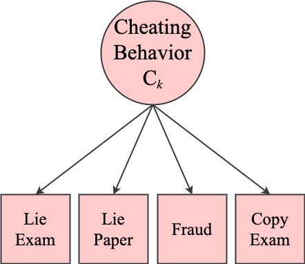

LCA indicators<sup>1</sup>

| Name | Label | Values |
| --- | --- | --- |
| LieExam | lied to avoid taking an exam | 0 = No, 1 = Yes |
| LiePaper | lied to avoid handing a term paper in on time | 0 = No, 1 = Yes |
| Fraud | purchased a term paper to hand in as their own or had obtained a copy of an exam prior to taking the exam | 0 = No, 1 = Yes |
| CopyExam | copied answers during an exam from someone sitting near to them | 0 = No, 1 = Yes |

<sup>*1*</sup> Undergraduate Cheating Behavior

Prepare data

```r
data(cheating)

cheating <- cheating %>% clean_names()

df_cheat <-  cheating %>%                                  #
  dplyr::select(1:4) %>%                                   #
  dplyr::mutate_all(funs(.-1))                             #
```

Run a quick LCA using `createMixtures`

```r
createMixtures(classes = 1:4, filename_stem = "cheat",                                       #
                  rdata = df_cheat,                                                          #
               ANALYSIS = "processors = 10; starts 500 100;",                                #
               VARIABLE = "CATEGORICAL = lieexam-copyexam; USEVAR = lieexam-copyexam;",      #
                   PLOT = "type = plot3; series = lieexam-copyexam(*);")                     #

files <- data.frame(names = list.files(path = here(), full.names = FALSE))

f_cheat <- files %>% dplyr::filter(., grepl('cheat', names))

for (i in 1:length(f_cheat)) { file.move(glue(here("{f_cheat[,i]}")), here("enum_mplus")) }
```

```r
runModels(here("enum_mplus"), filefilter = "cheat")
```

View model fit statistics with `mixtureSummaryTable()`

```r
output_cheat <- readModels(here("enum_mplus"), filefilter = "cheat", quiet = TRUE)

gt(mixtureSummaryTable(output_cheat)) %>%                                                         #
  tab_header(                                                                                     #
    title = "Fit Indices") %>%                                                                    #
  tab_options(                                                                                    #
    table.width = pct(80)) %>%                                                                    #
  tab_footnote(                                                                                   #
    footnote = "Undergraduate Cheating Behavior",                                                 #
    location = cells_title())                                                                     #
```

Fit Indices<sup>1</sup>

| Title | Classes | AIC | BIC | aBIC | Entropy | T11_VLMR_PValue | T11_LMR_PValue | BLRT_PValue | min_N | max_N | min_prob | max_prob |
| --- | --- | --- | --- | --- | --- | --- | --- | --- | --- | --- | --- | --- |
| 1 classes | 1 | 942.876 | 957.937 | 945.250 | NA | NA | NA | NA | 319 | 319 | 1.000 | 1.000 |
| 2 classes | 2 | 898.054 | 931.941 | 903.395 | 0.737 | 0.0000 | 0.0000 | 0.0000 | 54 | 265 | 0.818 | 0.955 |
| 3 classes | 3 | 900.471 | 953.184 | 908.779 | 0.840 | 0.1656 | 0.1784 | 0.1395 | 12 | 283 | 0.550 | 0.982 |
| 4 classes | 4 | 910.290 | 981.829 | 921.564 | 0.866 | 0.6868 | 0.6882 | 1.0000 | 6 | 290 | 0.390 | 0.992 |

<sup>*1*</sup> Undergraduate Cheating Behavior

Extract and prepare plot data

```r
# extract posterior probabilities
plot1 <- as.data.frame(output_cheat[["cheat_4_class.out"]][["gh5"]][["means_and_variances_data"]][["estimated_probs"]][["values"]][seq(2,
    8, 2), ])  #seq('from','to','by')

# extract class size proportions
c_size <- as.data.frame(output_cheat[["cheat_4_class.out"]][["class_counts"]][["modelEstimated"]][["proportion"]])

colnames(c_size) <- paste0("cs")

c_size <- c_size %>% mutate(cs = round(cs * 100, 2))

# rename columns (classes) and 'Var' (indicator names)
colnames(plot1) <- paste0("C", 1:4, glue(" ({c_size[1:4,]}%)"))
plot1 <- cbind(Var = paste0("U", 1:4), plot1)

# choose the order of indicators by changing to ordered factor
plot1$Var <- fct_inorder(plot1$Var)

# change dateframe from wide to long format
pd_long1 <- melt(plot1, id.vars = "Var")
```

Plot 4-class latent class posterior probability plot

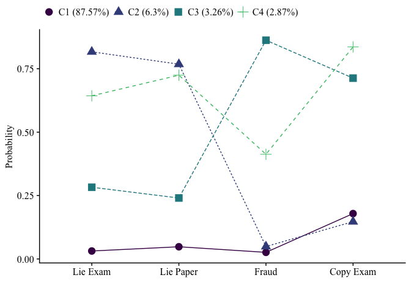

```r
ggplot(pd_long1, aes(Var, value, shape = variable,                                              #
                    colour = variable, lty = variable)) +                                       #
  geom_point(size = 4) + geom_line(aes(as.integer(Var))) +                                      #
  scale_x_discrete(labels = c("Lie Exam", "Lie Paper", "Fraud", "Copy Exam")) +                 #
  scale_y_continuous("Probability") +                                                           #
  scale_colour_viridis_d(end = .7) +                                                            #
  theme_cowplot() + labs(x=" ") +                                                               #
  theme(text=element_text(family="Times New Roman", size=12),                                   #
        legend.key.width = unit(.5, "line"),                                                    #
        legend.text = element_text(family="Times New Roman", size=12),                          #
        legend.title = element_blank(),                                                         #
        legend.position = "top")                                                                #
```

save figure

```r
ggsave(here("figures", "C4_Cheat_LCA_Plot.png"), dpi = "retina", height = 5, width = 7,
    units = "in")
```

## Example 2: Longitudinal Study of American Youth, **Science Attitudes**

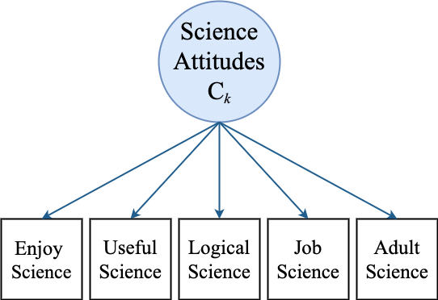

Load data

```r
lsay_data <- read_csv(here("data", "lca_lsay_sci.csv"), na = c("9999", "9999.00")) %>%               #
  clean_names() %>%                                                                                  #
  dplyr::select(1:5, Enjoy = ab39m, Useful = ab39t,                                                  #
                     Logical = ab39u, Job = ab39w, Adult = ab39x)                                    #
```

View LCA indicators

LCA Indicators<sup>1</sup>

| Name | Label | Values |
| --- | --- | --- |
| Enjoy | I enjoy science | 0 = Disagree, 1 = Agree |
| Useful | Science useful in everday problems | 0 = Disagree, 1 = Agree |
| Logical | Science helps logical thinkng | 0 = Disagree, 1 = Agree |
| Job | Need science for a good job | 0 = Disagree, 1 = Agree |
| Adult | Will use science often as an adult | 0 = Disagree, 1 = Agree |

<sup>*1*</sup> Longitudinal Study of American Youth

Run enumeration using `mplusObject` method

```r
lca_k1_6  <- lapply(1:6, function(k) {
  lca_enum  <- mplusObject(

    TITLE = glue("Class {k}"),

    VARIABLE = glue(
    "categorical = Enjoy-Adult;
     usevar = Enjoy-Adult;
     classes = c({k}); "),

  ANALYSIS =
   "estimator = mlr;
    type = mixture;
    stseed = 5212020;
    starts = 200 100;
    processors = 10;",

  OUTPUT = "sampstat residual tech11 tech14;",

  PLOT =
    "type = plot3;
    series = Enjoy-Adult(*);",

  usevariables = colnames(lsay_data),
  rdata = lsay_data)

lca_enum_fit <- mplusModeler(lca_enum,
                            dataout=glue(here("enum_mplus", "c_lca_lsay_Lab8.dat")),
                            modelout=glue(here("enum_mplus", "c{k}_lca_lsay_Lab8.inp")) ,
                            check=TRUE, run = TRUE, hashfilename = FALSE)
})
```

Compare model fit for series of enumerated models

```r
all_output <- readModels(here("enum_mplus"), filefilter = "lsay", quiet = TRUE)

enum_summary <- LatexSummaryTable(all_output,                                             #
                keepCols=c("Title", "LL", "BIC", "aBIC",                                  #
                           "BLRT_PValue", "T11_VLMR_PValue"),                             #
                sortBy = "Title")                                                         #

gt(enum_summary)  %>%                                                                     #
  tab_header(                                                                             #
    title = "Fit Indices" ) %>%                                                           #
  tab_options(                                                                            #
    table.width = pct(80)) %>%                                                            #
  tab_footnote(                                                                           #
    footnote = "Longitudinal Study of American Youth",                                    #
    location = cells_title())                                                             #
```

Fit Indices<sup>1</sup>

| Title | LL | BIC | aBIC | BLRT_PValue | T11_VLMR_PValue |
| --- | --- | --- | --- | --- | --- |
| Class 1 | -10250.604 | 20541.34 | 20525.45 | NA | NA |
| Class 2 | -8785.317 | 17658.92 | 17623.97 | 0 | 0.0000 |
| Class 3 | -8693.569 | 17523.59 | 17469.57 | 0 | 0.0000 |
| Class 4 | -8664.090 | 17512.79 | 17439.71 | 0 | 0.0000 |
| Class 5 | -8662.386 | 17557.54 | 17465.40 | 1 | 0.6734 |
| Class 6 | -8661.541 | 17604.01 | 17492.80 | 1 | 0.8384 |

<sup>*1*</sup> Longitudinal Study of American Youth

Compare probability plots for $K = 1:6$ class solutions

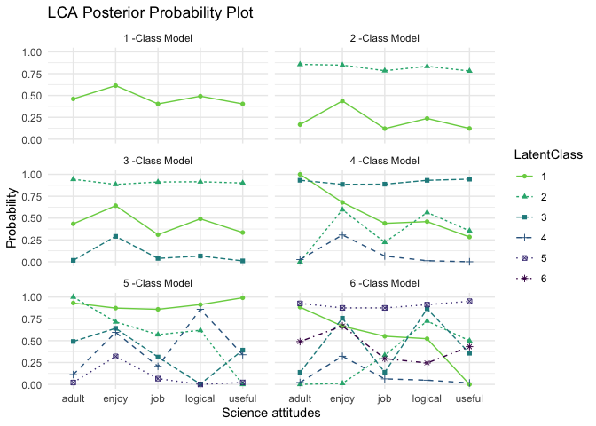

```r
model_results <- data.frame()

for (i in 1:length(all_output)) {

  temp <- all_output[[i]]$parameters$unstandardized %>%                                            #
    mutate(model = paste(i, "-Class Model"))                                                       #

  model_results <- rbind(model_results, temp)
}

rm(temp)

model_results <- model_results %>%                                                                 #
  filter(paramHeader == "Thresholds") %>%                                                          #
  dplyr::select(est, model, LatentClass, param) %>%                                                #
  mutate(prob = (1 / (1 + exp(est)))) %>%                                                          #
  mutate(param = as.factor(str_to_lower(str_sub(param, end = -3)))) %>%                            #
  dplyr::select(-est)                                                                              #

ggplot(model_results, aes(x = param, y = prob,                                                     #
           color = LatentClass, shape = LatentClass,                                               #
           group = LatentClass, lty = LatentClass)) +                                              #
  geom_point() + geom_line() +                                                                     #
  scale_colour_viridis_d(end = .8, direction = -1) +                                               #
  facet_wrap(~ model, ncol = 2) +                                                                  #
  labs(title = "LCA Posterior Probability Plot",                                                   #
       x= "Science attitudes", y = "Probability") +                                                #
  theme_minimal()                                                                                  #
```

```r
ggsave(here("figures", "Enum_LCA_facet_plot.png"), dpi = 300, height = 4, width = 6,
    units = "in")
```

## Example 3 - Kindergarten Student Entrance Profile (**KSEP**)

```r
ksep <- read_csv(here("data", "KSEP_sub_L6.18.csv"))
```

LCA Indicators<sup>1</sup>

| Name | Label | Values |
| --- | --- | --- |
| seek_hlp | Seeks adult help when appropriate | 0 = Not Mastered, 1 = Mastered |
| cooperat | Engages in cooperative play activities with peers | 0 = Not Mastered, 1 = Mastered |
| imp_cntr | Exhibits impulse control and self-regulation | 0 = Not Mastered, 1 = Mastered |
| repeats | Stays with or repeats a task | 0 = Not Mastered, 1 = Mastered |
| separate | Separates appropriately from caregiver most days | 0 = Not Mastered, 1 = Mastered |
| new_activ | Is enthusiastic and curious in approaching new activities | 0 = Not Mastered, 1 = Mastered |
| folw_rul | Follows rules when participating in routine activities | 0 = Not Mastered, 1 = Mastered |
| name | Recognizes own name | 0 = Not Mastered, 1 = Mastered |
| writes | Writes own name | 0 = Not Mastered, 1 = Mastered |
| express | Demonstrates expressive abilities | 0 = Not Mastered, 1 = Mastered |
| quantity | Understands that numbers represent quantity | 0 = Not Mastered, 1 = Mastered |
| colors | Recognizes Colors | 0 = Not Mastered, 1 = Mastered |
| shapes | Recognizes primary shapes | 0 = Not Mastered, 1 = Mastered |

<sup>*1*</sup> Kindergarten Student Entrance Profile

Enumeration: Compare *k*-class models 1-6

```r
lca_k1_6  <- lapply(1:6, function(k) {
  lca_enum  <- mplusObject(

    TITLE = glue("Class {k}"),

    VARIABLE = glue(
    "categorical = seek_hlp-shapes;
     usevar = seek_hlp-shapes;
     classes = c({k}); "),

  ANALYSIS =
   "estimator = mlr;
    type = mixture;
    stseed = 5212020;
    starts = 200 100;
    processors = 10;",

  OUTPUT = "sampstat residual tech11 tech14;",

  PLOT =
    "type = plot3;
    series = seek_hlp-shapes(*);",

  usevariables = colnames(ksep),
  rdata = ksep)

lca_enum_fit <- mplusModeler(lca_enum,
                            dataout=glue(here("enum_ksep", "c_lca_ksep_Lab8.dat")),
                            modelout=glue(here("enum_ksep", "c{k}_lca_ksep_Lab8.inp")) ,
                            check=TRUE, run = TRUE, hashfilename = FALSE)
})
```

Compare model fit for series of enumerated models

```r
all_output <- readModels(here("enum_ksep"), quiet = TRUE)

enum_summary <- LatexSummaryTable(all_output,                                              #
                keepCols=c("Title", "LL", "BIC", "aBIC",                                   #
                           "BLRT_PValue", "T11_VLMR_PValue"),                              #
                sortBy = "Title")                                                          #

gt(enum_summary) %>%                                                                       #
  tab_header(                                                                              #
    title = "Fit Indices") %>%                                                             #
  tab_options(                                                                             #
    table.width = pct(80)) %>%                                                             #
  tab_footnote(                                                                            #
    footnote = "Kindergarten Student Entrance Profile",                                    #
    location = cells_title())                                                              #
```

Fit Indices<sup>1</sup>

| Title | LL | BIC | aBIC | BLRT_PValue | T11_VLMR_PValue |
| --- | --- | --- | --- | --- | --- |
| Class 1 | -11844.461 | 23783.62 | 23742.32 | NA | NA |
| Class 2 | -9712.793 | 19622.26 | 19536.49 | 0 | 0.0000 |
| Class 3 | -9372.043 | 19042.74 | 18912.49 | 0 | 0.0000 |
| Class 4 | -9215.475 | 18831.58 | 18656.86 | 0 | 0.1240 |
| Class 5 | -9137.866 | 18778.34 | 18559.15 | 0 | 0.0722 |
| Class 6 | -9075.565 | 18755.71 | 18492.05 | 0 | 0.0394 |

<sup>*1*</sup> Kindergarten Student Entrance Profile

Compare probability plots for $K = 1:6$ class solutions

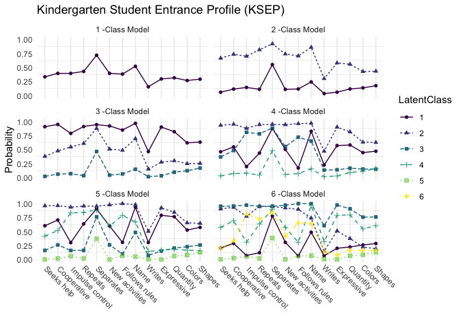

```r
model_results <- data.frame()

for (i in 1:length(all_output)) {

  temp <- all_output[[i]]$parameters$unstandardized %>%                                       #
    mutate(model = paste(i, "-Class Model"))                                                  #

  model_results <- rbind(model_results, temp)
}

rm(temp)

model_results <- model_results %>%                                                                         #
  filter(paramHeader == "Thresholds") %>%                                                                  #
  dplyr::select(est, model, LatentClass, param) %>%                                                        #
  mutate(prob = (1 / (1 + exp(est)))) %>%                                                                  #
  mutate(param = as.factor(str_to_lower(str_sub(param, end = -3)))) %>%                                    #
  dplyr::select(-est)                                                                                      #

model_results$param <- fct_inorder(model_results$param)

ggplot(model_results, aes(x = param, y = prob,                                                             #
           color = LatentClass, shape = LatentClass,                                                       #
           group = LatentClass, lty = LatentClass)) +                                                      #
  geom_point() + geom_line() +                                                                             #
  scale_colour_viridis_d() +                                                                               #
  facet_wrap(~ model, ncol = 2) +                                                                          #
  labs(title = "Kindergarten Student Entrance Profile (KSEP)",                                             #
       x= " ", y = "Probability") +                                                                        #
  scale_x_discrete(labels = c("Seeks help", "Cooperative", "Impulse control","Repeats", "Separates",       #
                     "New activities", "Follows rules", "Name", "Writes", "Expressive", "Quantity",        #
                     "Colors", "Shapes")) +                                                                #
  theme_minimal() + theme(panel.grid.major.y = element_blank(),                                            #
                          axis.text.x = element_text(angle = -45, hjust = -.1))                            #
```

```r
ggsave(here("figures", "KSEP_LCA_facet_plot.png"), dpi = 300, height = 4, width = 6,
    units = "in")
```

Extraxt and prepare plot data

```r
# extract posterior probabilities
plot1 <- as.data.frame(all_output[["c4_lca_ksep_Lab8.out"]]  #
[["gh5"]][["means_and_variances_data"]]  #
[["estimated_probs"]][["values"]]  #
[seq(2, 26,
    2), ])  #seq('from','to','by')                              #

# extract class size proportions
c_size <- as.data.frame(all_output[["c4_lca_ksep_Lab8.out"]][["class_counts"]][["modelEstimated"]][["proportion"]])

colnames(c_size) <- paste0("cs")

c_size <- c_size %>% mutate(cs = round(cs * 100, 2))

# rename columns (classes) and 'Var' (indicator names)
colnames(plot1) <- paste0("C", 1:4, glue(" ({c_size[1:4,]}%)"))
plot1 <- cbind(Var = paste0("U", 1:13), plot1)

# choose the order of indicators by changing to ordered factor
plot1$Var <- fct_inorder(plot1$Var)

# change dateframe fromw wide to long format
pd_long1 <- melt(plot1, id.vars = "Var")
```

Plot 4-class mixture

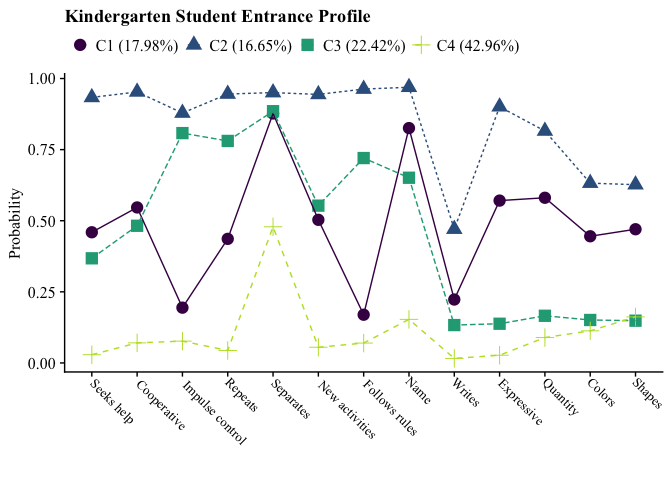

```r
ggplot(pd_long1, aes(Var, value, shape = variable,                                                   #
                    colour = variable, lty = variable)) +                                            #
  geom_point(size = 4) + geom_line(aes(as.integer(Var))) +                                           #
  scale_x_discrete(labels = c("Seeks help", "Cooperative", "Impulse control", "Repeats",             #
                              "Separates", "New activities", "Follows rules", "Name",                #
                              "Writes", "Expressive", "Quantity", "Colors", "Shapes")) +             #
  scale_y_continuous("Probability") +                                                                #
  scale_colour_viridis_d(end = .9) +                                                                 #
  labs(title="Kindergarten Student Entrance Profile", x=" ") +                                       #
  theme_cowplot() +                                                                                  #
  theme(text=element_text(family="Times New Roman", size=12),                                        #
       legend.key.width = unit(.5, "line"),                                                          #
       legend.text = element_text(family="Times New Roman", size=12),                                #
       legend.title = element_blank(),                                                               #
       axis.text.x = element_text(angle = -45, hjust = -.1, size=10),                                #
       legend.position = "top")                                                                      #
```

```r
ggsave(here("figures","Class4_KSEP_LCA_plot.png"),             #
       dpi=300, height=4, width=6, units="in")                 #
```

# [Lab Materials - Return to Home Page](https://garberadamc.github.io/project-site/)

# References

Drew A. Linzer, Jeffrey B. Lewis (2011). poLCA: An R Package for Polytomous Variable Latent Class Analysis. Journal of Statistical Software, 42(10), 1-29. URL http://www.jstatsoft.org/v42/i10/.

Hallquist, M. N., & Wiley, J. F. (2018). MplusAutomation: An R Package for Facilitating Large-Scale Latent Variable Analyses in Mplus. Structural equation modeling: a multidisciplinary journal, 25(4), 621-638.

Miller, J. D., Hoffer, T., Suchner, R., Brown, K., & Nelson, C. (1992). LSAY codebook. Northern Illinois University.

Muthén, B. O., Muthén, L. K., & Asparouhov, T. (2017). Regression and mediation analysis using Mplus. Los Angeles, CA: Muthén & Muthén.

Muthén, L.K. and Muthén, B.O. (1998-2017). Mplus User’s Guide. Eighth Edition. Los Angeles, CA: Muthén & Muthén

Quirk, M., Furlong, M., Lilles, E., Felix, E., & Chin, J. (2011). Preliminary development of a kindergarten school readiness assessment for Latino students. Journal of Applied School Psychology, 27(1), 77-102.

R Core Team (2017). R: A language and environment for statistical computing. R Foundation for Statistical Computing, Vienna, Austria. URL http://www.R-project.org/

Wickham et al., (2019). Welcome to the tidyverse. Journal of Open Source Software, 4(43), 1686, https://doi.org/10.21105/joss.01686